# Information Needs for Identifying Bug-introducing changes

### Demographic Information of Participants

#### Which affirmations are related to the reported bugs?

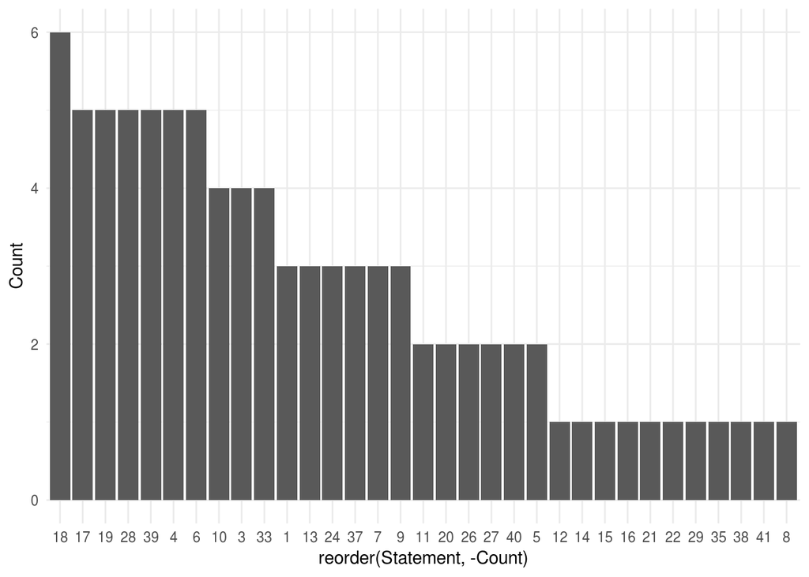

#### List of Statements:

- 1-Understanding the rationale behind changes is mandatory to avoid the bugs introduction.
- 2-Changes that neglect non-functional requirements are more likely to introduce bugs.
- 3-Having documentation associated with source code is decisive for developers to avoid bug-introducing changes on it.
- 4-Familiarity of developers with source code is mandatory to avoid bug-introducing changes.
- 5-Changes involving a large number of files are more likely to introduce bugs.
- 6-When reviewing a change- reviewers need to be aware of all artifacts impacted by this change to avoid the introduction of bugs.
- 7-Changes invoking a high number of features (methods, fields, classes) are more likely to introduce bugs
- 8-Changes with high test coverage introduce less bugs.
- 9-Having a testing team is mandatory to avoid bug-introducing changes.
- 10-Automated testing reduces considerably the introduction of bugs.
- 11-Manual tests verify which changes meet user requirements. Therefore, manual testing is mandatory to avoid bugs.
- 12-Continuous integration is mandatory to avoid bug-introducing changes.
- 13-Using software quality assurance (SQA) methods in the code review process is decisive to avoid bug-introducing changes
- 14-Changes that break the software architectural design are more likely to introduce bugs.
- 15-Changes containing code smells are more likely to introduce bugs.
- 16-Avoiding recurring changes reduce the introduction of bugs.
- 17-Before accepting pull-requests, it is mandatory to compile and run the system with the changes to avoid the introduction of bugs.
- 18-Familiarity of developers with the programming language adopted in a project is mandatory to avoid bugs.
- 19-Code reviews reduce considerably the introduction of bugs.
- 20-Developers working on legacy code introduce more bugs.
- 21-Adopting pair programming is decisive to avoid bug-introducing changes.
- 22-Agile methods aim at reducing the delivery lifecycle. Therefore, when adopting these methods, developers are more likely to perform bug-introducing changes.
- 23,Code snippets frequently changed are hotspots of bugs.
- 24-Understanding the software history is mandatory for developers to avoid the introduction of bugs.
- 25-Code reuse avoids the introduction of bugs.
- 26-Handling the exceptions associated with a change is mandatory to avoid the introduction of bugs.
- 27-Using static analysis tools is decisive to avoid bug-introducing changes.
- 28-Experienced developers introduce less bugs.
- 29-Fixing bugs is riskier (more likely to introduce bugs) than adding new features.
- 30-Floss refactorings tend to introduce bugs. This refactoring consists of refactoring the code together with non-structural changes as a means to reach other goals, such as adding features or removing bugs.
- 31-Root-canal refactorings are less prone to introduce bugs. This refactoring is used for strictly improving the source code structure and consists of pure refactoring.
- 32-Adaptive changes are more likely to introduce bugs. These changes aim at migrating systems to a new version of a third party API.
- 33-Developers working on his own code are less likely to introduce bugs.
- 34-Merge commits introduce more bugs than other commits.
- 35-Conflicting changes introduce more bugs than non-conflicting ones.
- 36-Developers working on code snippets containing third-party APIs tend to introduce bugs.
- 37-Introduction of bugs depends on which programming language is used.
- 38-Geographically distributed teams introduce more bugs than teams that are not geographically distributed.
- 39-Developer’s specific experience in the project is more decisive to avoid the introduction of bugs than overall general experience in programming.
- 40-Code written in a language with static typing (e.g., C#) introduces fewer bugs than code written in a language with dynamic typing (e.g., Python).
- 41-Code snippet changed by different developers is hotspot of bugs.

#### General experience of participants:

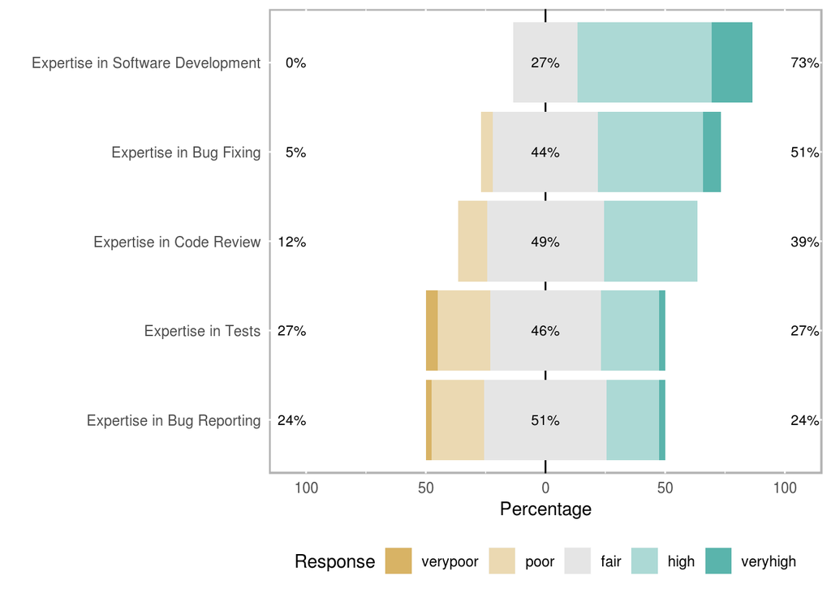

#### Educational Level of Participants

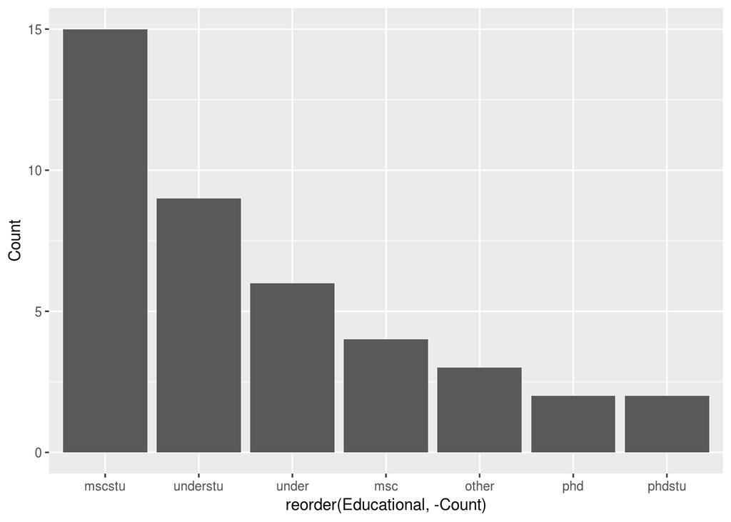

#### Job of Participants

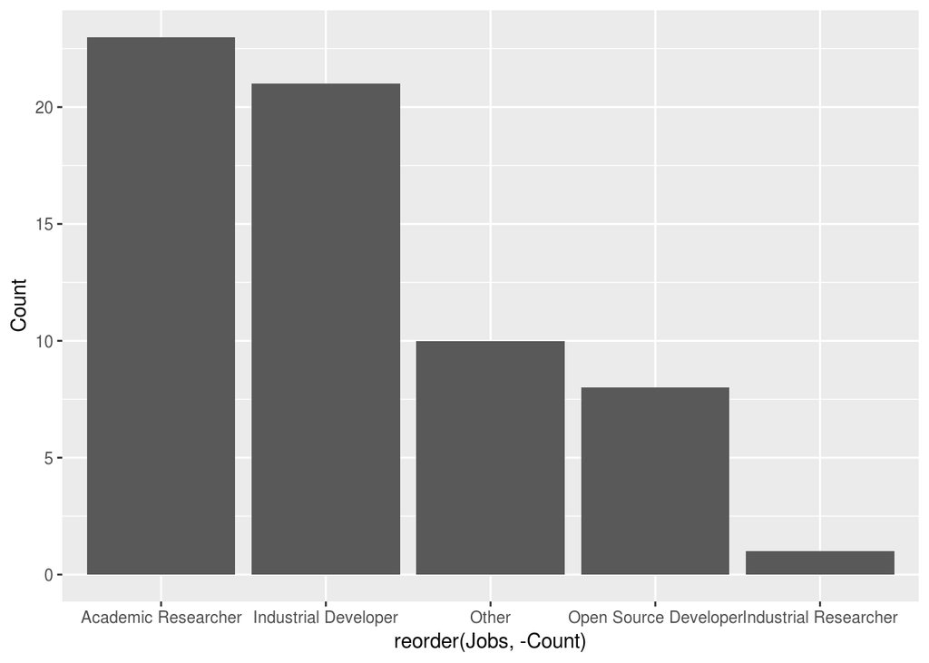

#### Individual Comments of Participants

##### Qestions:

- *input_buggy:* Could you provide the links of commits, issues or pull requests of this buggy code?
- *input_open:* Have you ever contributed for open source projects? If yes, could you provide the links of these projects?
- *text_buggy:* During a software development did you notice any changes that introduced bugs? If yes, how did you perceive the buggy code?

A Table

[output not shown]

### *Demographic Information by Factors [Grouping Dev’s]*

#### **Developers Loaded in Factor A:**

Degree (Factor A):

| edu | Frequency | percent |
| --- | --- | --- |
| mscstu | 4 | 36.363636 |
| msc | 2 | 18.181818 |
| understu | 2 | 18.181818 |
| other | 1 | 9.090909 |
| phd | 1 | 9.090909 |
| under | 1 | 9.090909 |

Jobs (Factor A):

| selectedJobs | Frequency | percent |
| --- | --- | --- |
| Industrial Developer | 3 | 27.27273 |
| Academic Researcher | 2 | 18.18182 |
| Industrial Developer,Open Source Developer | 2 | 18.18182 |
| Industrial Developer,Other | 2 | 18.18182 |
| Other | 2 | 18.18182 |

Expertise (Factor A):

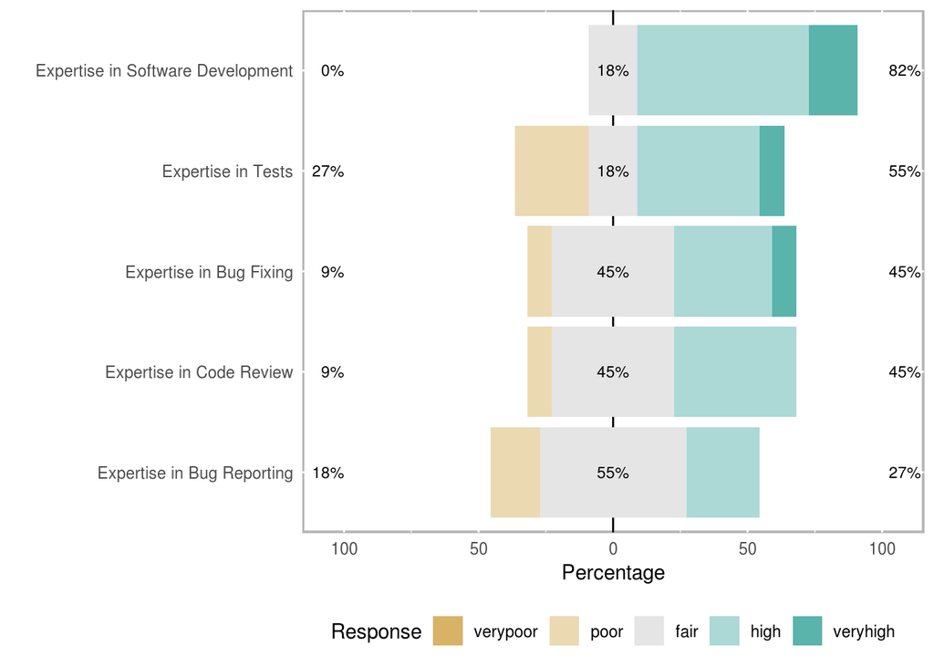

#### **Developers Loaded in Factor B:**

Degree (Factor B):

| edu | Frequency | percent |
| --- | --- | --- |
| mscstu | 2 | 40 |
| under | 2 | 40 |
| understu | 1 | 20 |

Jobs (Factor B):

| selectedJobs | Frequency | percent |
| --- | --- | --- |
| Academic Researcher | 1 | 20 |
| Academic Researcher,Industrial Developer | 1 | 20 |
| Academic Researcher,Industrial Developer,Industrial Researcher | 1 | 20 |
| Industrial Developer | 1 | 20 |
| Open Source Developer | 1 | 20 |

Expertise (Factor B):

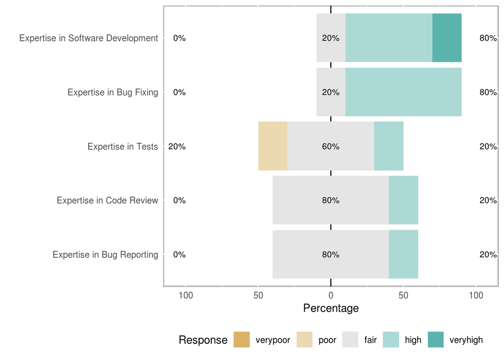

#### **Developers Loaded in Factor C:**

Degree (Factor C):

| edu | Frequency | percent |
| --- | --- | --- |
| mscstu | 4 | 66.66667 |
| understu | 2 | 33.33333 |

Jobs (Factor C):

| selectedJobs | Frequency | percent |
| --- | --- | --- |
| Academic Researcher | 1 | 16.66667 |
| Academic Researcher,Industrial Developer,Other | 1 | 16.66667 |
| Academic Researcher,Open Source Developer | 1 | 16.66667 |
| Industrial Developer | 1 | 16.66667 |
| Industrial Developer,Other | 1 | 16.66667 |
| Open Source Developer | 1 | 16.66667 |

Expertise (Factor C):

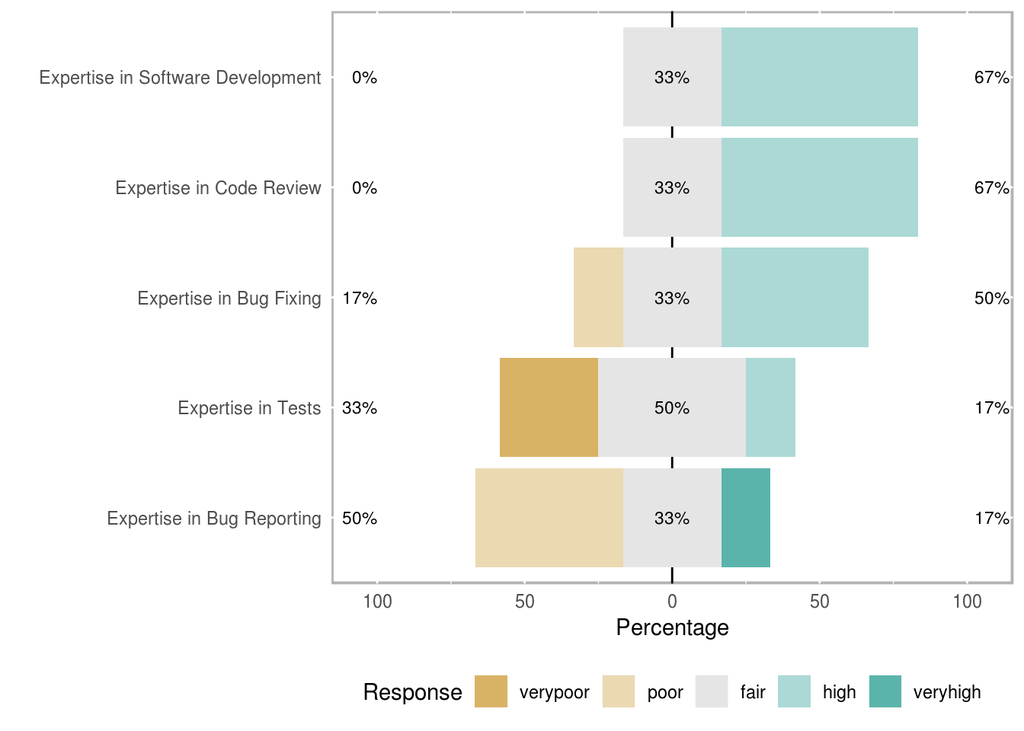

#### **Developers Loaded in Factor D:**

Degree (Factor D):

| edu | Frequency | percent |
| --- | --- | --- |
| mscstu | 1 | 33.33333 |
| under | 1 | 33.33333 |
| understu | 1 | 33.33333 |

Jobs (Factor D):

| selectedJobs | Frequency | percent |
| --- | --- | --- |
| Academic Researcher | 2 | 66.66667 |
| Academic Researcher,Industrial Developer | 1 | 33.33333 |

Expertise (Factor D):

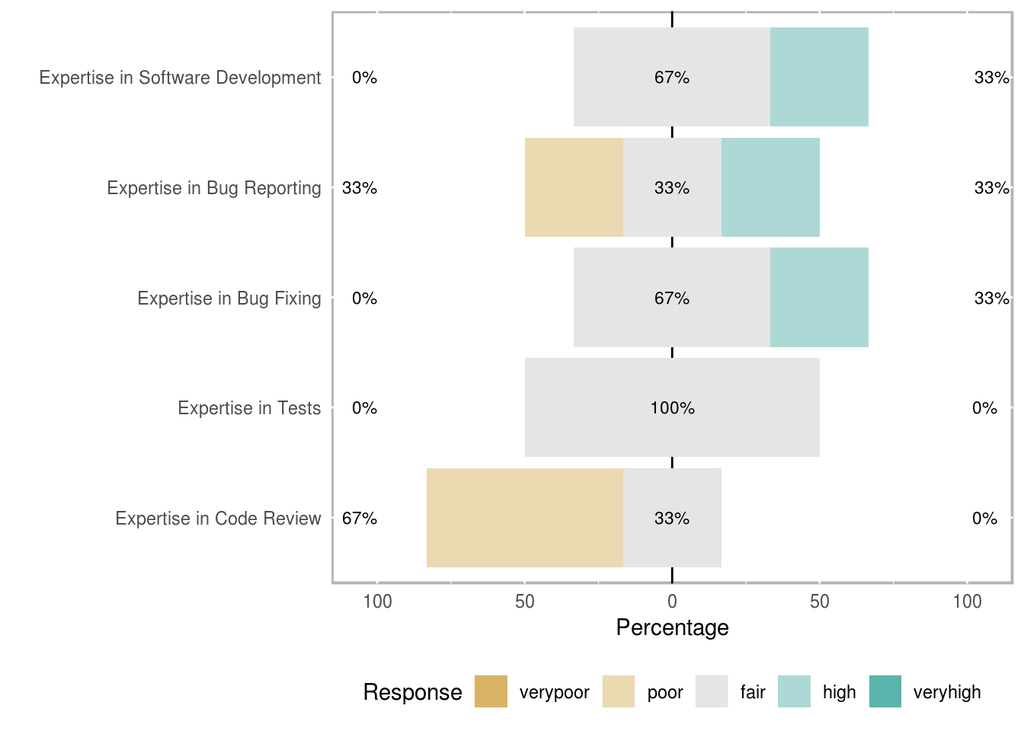

#### **Developers Loaded in Factor E:**

Degree (Factor E):

| edu | Frequency | percent |
| --- | --- | --- |
| other | 2 | 50 |
| understu | 2 | 50 |

Jobs (Factor E):

| selectedJobs | Frequency | percent |
| --- | --- | --- |
| Academic Researcher | 1 | 25 |
| Academic Researcher,Other | 1 | 25 |
| Industrial Developer | 1 | 25 |
| Other | 1 | 25 |

Expertise (Factor E):

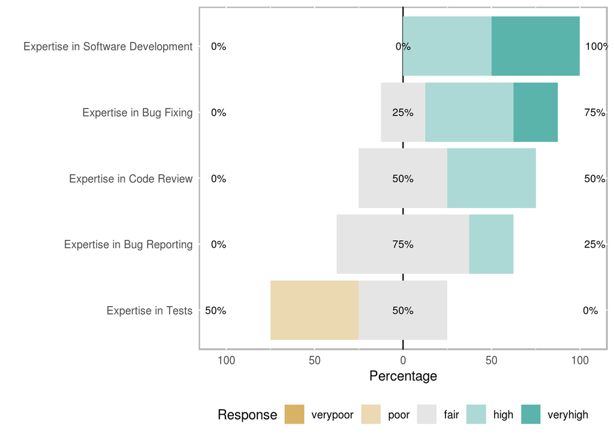